# Models Categorical Variables and Nonlinear Response

Steve Elston

10/27/2022

# Review

Linear models are a flexible and widely used class of models

- Fit model coefficients by **least squares** estimation
- Can use many types of predictor variables
- We prefer the simplest model that does a reasonable job
  - The principle of **Occam’s razor**
- Must consider the **bias-variance trade-off**

# Review

When evaluating any machine learning model consider **all evaluation methods available**

- No one method best all of the time
  - Homoskedastic Normally distributed residuals
  - Reasonable values $R^2$, RMSE, etc
  - Are the model coefficients all significant?
- **Different methods highlight different problems** with your model
- Don’t forget to check that the **model must make sense** for your application!

# Review

Representation of machine learning models

- The key representation is the model matrix
  - Column of 1s for intercept
  - Columns of feature or predictor values

$$A =
\begin{bmatrix}
1, x_{1,1}, x_{1,2}, \ldots, x_{1,p}\\
1, x_{2,1}, x_{2,2}, \ldots, x_{2,p}\\
1, x_{3,1}, x_{3,2}, \ldots, x_{3,p}\\
\vdots,\ \vdots,\ \vdots,\ \vdots,\ \vdots\\
1, x_{n,1}, x_{n,2}, \ldots, x_{n,p}
\end{bmatrix}$$

- There are two standards for signatures of ML functions
  - A model matrix $X$ (exogenous-features) and label array $Y$ (dependent-endogenous) - Scikit-learn and base Statsmodels
  - A data frame with all features (predictors) and label (dependent) columns plus a model formula - Statsmodels formula and R

# Review

There are a number of assumptions in linear models that you overlook at your peril!

- The feature or predictor variables should be **independent** of one another
  - This is rarely true in practice
  - **Multi-collinearity** between features makes the model **under-determined**
- We assume that numeric features or predictors have **zero mean** and about the **same scale**
  - We do not want to bias the estimation of regression coefficients with predictors that do not have a 0 mean
  - We do not want to have predictors with a large numeric range dominate training
  - Example: income is in the range of 10s or 100s of thousands and age is in the range of 10s, but apriori income is no more important than age as a predictor
- Values of each predictor or feature should be iid
  - If variance changes with sample, the optimal value of the coefficient could not be constant
  - If there **serial correlation** in the predictor values, the iid assumption is violated - but can account for this such as in time series models

# Review

Scaling of features is required for many machine learning models

- Several commonly used approaches
  - **Z-score** scaling results in features with zero mean and unit variance
  - Use Z-score scaling for features approximately normally distributed
  - **Min-max** scaling transforms feature values to range 0-1
  - Use min-max scaling for features with truncated range of values
- Effect on model coefficients
  - Scaling changes model coefficients by the scale factor applied
  - Can re-scale (unscale) model coefficients before processing unknown cases
  - Or use **same scaling** for unknown feature values
- When coding categorical variables as binary dummy variables no need to scale - already in range [0-1]

# Introduction

- Working with categorical variables
  - One-hot encoding
  - Working with contrasts
  - Effects and adjustments
- Building models with nonlinear or non-Normal response
  - Use generalized linear model for nonlinear response
  - Link function transforms to nonlinear model to linear model
  - Evaluating Binomial response models
  - Compare model performance with deviance
  - Poisson regression

# Working with Categorical Variables

Linear models, like nearly all machine learning models, use numeric features

- How can categorical variables be used in linear models?
- Need to transform categories to numeric variables with **one hot encoding**
  - Each category becomes a binary **dummy variable**, encoded [0,1]
  - Only one dummy variable has nonzero value - encodes the category
  - n categories represented by n-1 dummy variables; all 0s encodes one level
- Binary variables are an exception
  - Represent with a single binary variable. [0,1] values

# Working with Categorical Variables

Example: Consider a data set with categorical variables

```
##     id  female  race  ses  schtyp  prog  read  write  math  science  socst
## 0   70       0     4    1       1     1    57     52    41       47     57
## 1  121       1     4    2       1     3    68     59    53       63     61
## 2   86       0     4    3       1     1    44     33    54       58     31
## 3  141       0     4    3       1     3    63     44    47       53     56
## 4  172       0     4    2       1     2    47     52    57       53     61
## 5  113       0     4    2       1     2    44     52    51       63     61
## 6   50       0     3    2       1     1    50     59    42       53     61
## 7   11       0     1    2       1     2    34     46    45       39     36
## 8   84       0     4    2       1     1    63     57    54       58     51
## 9   48       0     3    2       1     2    57     55    52       50     51
```

# Working with Categorical Variables

Example: split the data into train and test subsets

```python
nr.seed(2345)
msk = nr.choice(test_scores.index, size = 120, replace=False)
test_scores_train = test_scores.iloc[msk,:]
print(test_scores_train.shape)
```

```
## (120, 11)
```

```python
test_scores_test = test_scores.drop(msk, axis=0)
print(test_scores_test.shape)
```

```
## (80, 11)
```

# Working with Categorical Variables

Example: We can encode a categorical variable with the Python patsy package to get the X (model) and Y(label) arrays:

```python
from patsy import dmatrices
Y, X = dmatrices("socst ~ C(ses, levels=[1,2,3])", data=test_scores)
print(X[:5])
```

```
## [[1. 0. 0.]
##  [1. 1. 0.]
##  [1. 0. 1.]
##  [1. 0. 1.]
##  [1. 1. 0.]]
```

```python
print(Y[:5])
```

```
## [[57.]
##  [61.]
##  [31.]
##  [56.]
##  [61.]]
```

# Working with Categorical Variables

Example: A simple linear model with one categorical variable

```python
import statsmodels.formula.api as smf
linear_model = smf.ols("socst ~ C(ses)", data=test_scores_train).fit()
linear_model.summary()
```

```
## <class 'statsmodels.iolib.summary.Summary'>
## """
##                             OLS Regression Results
## ==============================================================================
## Dep. Variable:                  socst   R-squared:                       0.097
## Model:                            OLS   Adj. R-squared:                  0.082
## Method:                 Least Squares   F-statistic:                     6.285
## Date:                Thu, 27 Oct 2022   Prob (F-statistic):            0.00255
## Time:                        17:54:13   Log-Likelihood:                -446.60
## No. Observations:                 120   AIC:                             899.2
## Df Residuals:                     117   BIC:                             907.6
## Df Model:                           2
## Covariance Type:            nonrobust
## ===============================================================================
##                   coef    std err          t      P>|t|      [0.025      0.975]
## -------------------------------------------------------------------------------
## Intercept      47.5926      1.949     24.415      0.000      43.732      51.453
## C(ses)[T.2]     4.8635      2.366      2.055      0.042       0.177       9.550
## C(ses)[T.3]     9.1296      2.579      3.540      0.001       4.023      14.237
## ==============================================================================
## Omnibus:                        3.392   Durbin-Watson:                   2.023
## Prob(Omnibus):                  0.183   Jarque-Bera (JB):                3.413
## Skew:                          -0.397   Prob(JB):                        0.182
## Kurtosis:                       2.772   Cond. No.                         4.53
## ==============================================================================
##
## Notes:
## [1] Standard Errors assume that the covariance matrix of the errors is correctly specified.
## """
```

# Working with Categorical Variables

Wait! What happened to the coefficient for the first level of ses?

- The intercept is the **mean response** of the first level
- The other coefficients are **contrasted** with respect to the mean of the first level.
- Consider the following possible ways we can encode responses to a categorical variable - often called a **treatment**
  - For $n$ treatments, there are mean responses $[ \mu_1, \mu_2, \ldots, \mu_n ]$
  - The alternative encoding is a treatment with intercept, $I$, at $n - 1$ **contrasts**, $[ I, c_1, \ldots, c_{n-1}]$
- The means and contrasts are related:

$$\begin{bmatrix}
I\\
c_2\\
\vdots\\
c_n
\end{bmatrix} =
\begin{bmatrix}
\mu_1\\
\mu_2 - \mu_1\\
\vdots\\
\mu_n - \mu_1
\end{bmatrix}$$

# Working with Categorical Variables

In a linear model we can sometimes relate the coefficient values to an effect size

- Start with $n$ treatments $[t_1, t_2, \ldots, t_n ]$ with effect sizes, $[e_1, e_2, \ldots, e_n ]$
- With **no intercept term** the means represent the effect sizes:

$$\begin{bmatrix}
e_1\\
e_2\\
\vdots\\
e_n
\end{bmatrix} =
\begin{bmatrix}
\mu_1\\
\mu_2\\
\vdots\\
\mu_n
\end{bmatrix}$$

- With intercept term compute effect sizes using contrasts:

$$\begin{bmatrix}
e_1\\
e_2\\
\vdots\\
e_n
\end{bmatrix} =
\begin{bmatrix}
I\\
I + c_1\\
\vdots\\
I + c_{n}
\end{bmatrix}$$

# Working with Categorical Variables

In a linear model we can sometimes relate the coefficient values to an effect size

- Assumes the treatments are orthogonal
  - In other words, applied on at a time
  - e.g. a case can only be in one category
- Assumes that the model coefficients are statistically independent
  - Coefficients are dependent in overfit model
- Often need to **adjust** for other effects
  - Other treatments
  - Levels of other categorical variables
  - Use **partial slope** of continuous variables
- In other words **apply** with care!
  - Don’t over-interpret your model
  - Conditions in real world hard to verify, particularly for observational data

# Models with Nonlinear Response

How do we deal with models that do not have nonlinear response variables?

- Example: binary response variable, $[0,1]$, $Bin(\theta)$ distributed
  - Probability parameter $\theta$
  - A binary classifier
- Example: Intensity of an arrival process, $poisson(\lambda)$ response
  - $\lambda$ is the average rate or **intensity** of a point process
  - Estimate the parameter $\lambda$
- Example: Categorical response variable for $n$ categories, $Multi(\pi_1, \pi_2, \ldots, \pi_n)$:
  - $n$ category classifier
  - Response is probability probability for each category, $\Pi = [\pi_1, \pi_2, \ldots, \pi_n]$

# Models with Nonlinear Response

The **generalized linear model (GLM)** is a framework for nonlinear response models

- Nonlinear response is non-Normally distributed
- For each distribution use a **link function** to transform to a linear model
  - Linear model has Normally distributed response
  - Link function transform nonlinear response to Normal distribution
- To compute the nonlinear response
  - Start with a linear model, OLS
  - Transform response with **inverse link function**
  - Works for all exponential family response distributions

# The Generalized Linear Model

Link functions are available for many distributions

- Supported in [statsmodels](https://www.statsmodels.org/stable/glm.html)
- Supported in [Scikit-Learn](https://scikit-learn.org/stable/modules/linear_model.html#generalized-linear-regression)
- Examples:
  - Gaussian, identity function
  - Inverse Gaussian
  - Binomial, logit function
  - Multinomial
  - Poisson
  - Negative Binomial
  - Gamma
  - Tweedie

# The Generalized Linear Model

General form for link function, $g()$, mapping response variable, $y$, observation vector, $x$, to linear model

- Given linear model $\hat{\lambda} = \beta_0 + \beta_1\ x$:

$$g \big( \mathtt{E}[y_i|x_i] \big) =
\hat{\lambda} = \beta_0 + \beta_1\ x$$

- To find the value of the response variable we apply the inverse link function:

$$\mathtt{E}[y_i|x_i] = g^{-1} \big(
\hat{\lambda} \big) = g^{-1} \big( \beta_0 + \beta_1\ x \big)$$

# The Generalized Linear Model

OLS has Normal response

- What is the link function
- Link function for OLS is just unity, or $1$
- Output of linear model directly maps to Normally distributed response

$$\beta_0 + \beta_1\ x \sim N(\beta_0 +
\beta_1\ x, \sigma)$$

# The Logistic Regression Model

Construct a generalized linear model using a **Binomial distribution**

- Commonly known as [**logistic regression**](https://en.wikipedia.org/wiki/Logistic_regression)
- Logistic regression widely used as a classification model
- Logistic regression is linear model, with a binary response or label values, `{False, True}` or `{0, 1}`
- Response computed as a log likelihood, leading to a Binomial distributed response

# The Logistic Regression Model

Construct logistic regression as a GLM

- Start with a model for the log-odds of response $1$ vs. $0$
  - Probability of success, or $y_i = 1$, $p_i$
  - Independent variable vector $x_i$
  - Model parameter vector, $\mathbf{\beta}$
  - Binary response, $y_i = [0,1] \sim Bin(p_i)$
- Define the link function, know as the or **logit function**:

$$logit(\mathtt{E}[y_i|x_i]) =
logit(p_i(x_i)) = ln \Big(\frac{p_i(x_i)}{1-p_i(x_i)} \Big) =\beta_0 +
\mathbf{\beta} 𝑥_i$$

# The Logistic Regression Model

Response of linear model is transformed to the binomially distributed random variable through the **inverse link function**

- Known as the **inverse logit function**, or **logistic function**, $f(x_i)$
- After some algebra we can arrive at:

$$\begin{align}
\lambda_i &= \beta_0 + \mathbf{\beta} 𝑥_i\\
p_i(x_i) = \mathtt{E}[y_i|x_i] &= f(\lambda_i) =
logit^{-1}(\lambda_i) \\
p_i(x_i) = f(x_i) &= logit^{-1}(\lambda_i) = \frac{1}{1 +
e^{-\lambda_i}} = \frac{1}{1 + e^{-(\beta_0 + \mathbf{\beta} 𝑥_i)}}
\end{align}$$

# Logistic Regression Model

What does the transformation function look like?

- Consider a simple 1-dimensional case

$$y_i = \frac{1}{1 +
e^{-x_i}}$$

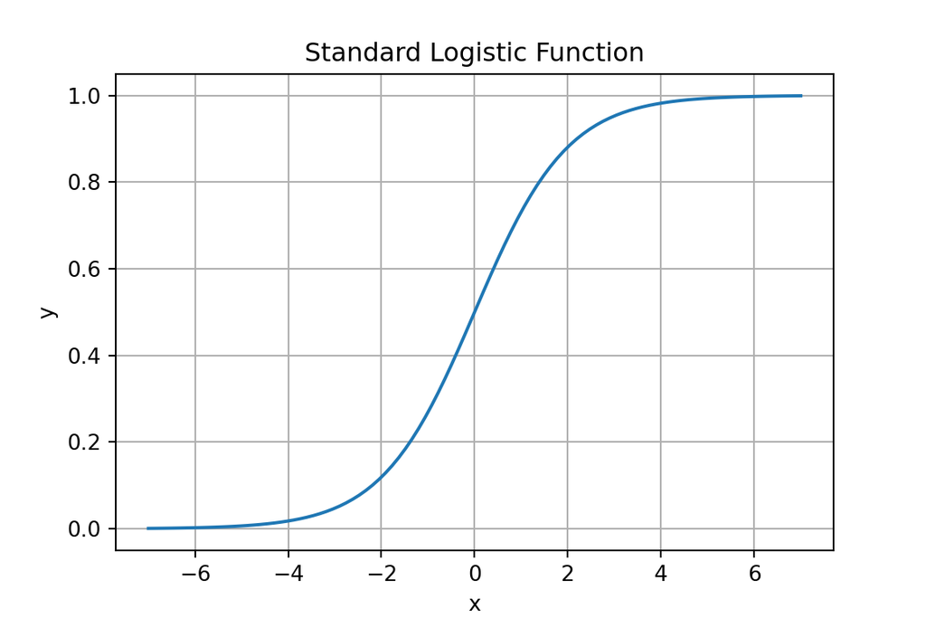

- The response is bound in the range $[0,1]$
- We say the logistic transformation **squashes** the linear response $\lambda =A \vec{b}$ to binary, $[0,1]$
- Can set a **decision threshold** for binary response
  - Default $= 0.5$

# Evaluation of Classifiers

How can we evaluate a classifier’s accuracy?

- Determine proportions of test cases which are classified as:
  - True Positives (TP): Are positive and should be positive
  - True Negatives (TN): Are negative and should be negative
  - False Positives (FP): Classified as positive but are actually negative; **Type I errors**
  - False Negatives (FN): Classified as negative but are actually positive; **Type II errors**
- Organize these metrics into a **confusion matrix**

|  | Classified Negative | Classified Positive |
| --- | --- | --- |
| Negative | TN | FP |
| Positive | FN | TP |

# Evaluation of Classifiers

# Example of Logistic Regression

How well can we predict the type of school given the test scores?

```python
## Prep the data
test_scores['schtyp'] = np.subtract(test_scores['schtyp'], 1)

## Fit the model
formula = 'schtyp ~ math'
logistic_reg_model = smf.glm(formula=formula, data=test_scores, family=sm.families.Binomial()).fit()

print(logistic_reg_model.summary())
```

```
##                  Generalized Linear Model Regression Results
## ==============================================================================
## Dep. Variable:                 schtyp   No. Observations:                  200
## Model:                            GLM   Df Residuals:                      198
## Model Family:                Binomial   Df Model:                            1
## Link Function:                  Logit   Scale:                          1.0000
## Method:                          IRLS   Log-Likelihood:                -86.978
## Date:                Thu, 27 Oct 2022   Deviance:                       173.96
## Time:                        17:54:14   Pearson chi2:                     199.
## No. Iterations:                     4   Pseudo R-squ. (CS):           0.009511
## Covariance Type:            nonrobust
## ==============================================================================
##                  coef    std err          z      P>|z|      [0.025      0.975]
## ------------------------------------------------------------------------------
## Intercept     -3.1718      1.129     -2.809      0.005      -5.385      -0.959
## math           0.0283      0.020      1.382      0.167      -0.012       0.068
## ==============================================================================
```

# Example of Logistic Regression

The data frame now looks like this with the predicted probability and the binary scores:

```python
## score the results
threshold=0.18
test_scores['predicted'] = logistic_reg_model.predict()
test_scores['score'] = [1 if x>threshold else 0 for x in test_scores['predicted']]

test_scores.head(20)
```

```
##      female  race  ses  schtyp  prog  ...  math  science  socst  predicted  score
## id                                    ...
## 70        0     4    1       0     1  ...    41       47     57   0.117996      0
## 121       1     4    2       0     3  ...    53       63     61   0.158163      0
## 86        0     4    3       0     1  ...    54       58     31   0.161968      0
## 141       0     4    3       0     3  ...    47       53     56   0.136844      0
## 172       0     4    2       0     2  ...    57       53     61   0.173824      0
## 113       0     4    2       0     2  ...    51       63     61   0.150772      0
## 50        0     3    2       0     1  ...    42       53     61   0.120973      0
## 11        0     1    2       0     2  ...    45       39     36   0.130295      0
## 84        0     4    2       0     1  ...    54       58     51   0.161968      0
## 48        0     3    2       0     2  ...    52       50     51   0.154432      0
## 75        0     4    2       0     3  ...    51       53     61   0.150772      0
## 60        0     4    2       0     2  ...    51       63     61   0.150772      0
## 95        0     4    3       0     2  ...    71       61     71   0.238200      1
## 104       0     4    3       0     2  ...    57       55     46   0.173824      0
## 38        0     3    1       0     2  ...    50       31     56   0.147184      0
## 115       0     4    1       0     1  ...    43       50     56   0.124015      0
## 76        0     4    3       0     2  ...    51       50     56   0.150772      0
## 195       0     4    2       1     1  ...    60       58     56   0.186356      1
## 114       0     4    3       0     2  ...    62       55     61   0.195090      1
## 85        0     4    2       0     1  ...    57       53     46   0.173824      0
##
## [20 rows x 12 columns]
```

# Example of Logistic Regression

Now, evaluate the model - the classifier is almost useless - **no Kagle awards!**:

```python
import sklearn.metrics as sklm
def print_metrics(labels, scores):
    metrics = sklm.precision_recall_fscore_support(labels, scores)
    conf = sklm.confusion_matrix(labels, scores)
    print('                 Confusion matrix')
    print('                 Score negative    Score positive')
    print('Actual negative    %6d' % conf[0,0] + '             %5d' % conf[0,1])
    print('Actual postitive    %6d' % conf[1,0] + '             %5d' % conf[1,1])
    print('')
    print('Accuracy  %0.2f' % sklm.accuracy_score(labels, scores))
    print(' ')
    print('           Negative      Positive')
    print('Num case   %6d' % metrics[3][0] + '        %6d' % metrics[3][1])
    print('Precision  %6.2f' % metrics[0][0] + '        %6.2f' % metrics[0][1])
    print('Recall     %6.2f' % metrics[1][0] + '        %6.2f' % metrics[1][1])
    print('F1         %6.2f' % metrics[2][0] + '        %6.2f' % metrics[2][1])

print_metrics(test_scores['schtyp'], test_scores['score'])
```

```
##                  Confusion matrix
##                  Score negative    Score positive
## Actual negative       127                41
## Actual postitive        22                10
##
## Accuracy  0.69
##
##            Negative      Positive
## Num case      168            32
## Precision    0.85          0.20
## Recall       0.76          0.31
## F1           0.80          0.24
```

# Example of Logistic Regression

How can we understand the cut-off value in terms of the CDF of the positive and negative cases?

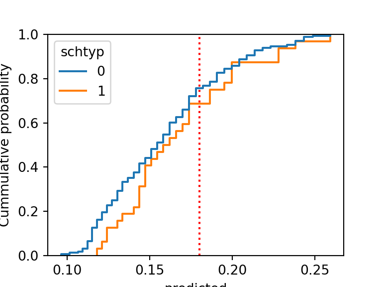

- Both CDFs are at 1.0 by about probability = 0.25 - this is a very skewed situation!
- CDF curves nearly the same = poor model
- Positive cases to the left of cut-off are Type II errors
- Negative cases to the right of cut-off are Type I errors

# What is Deviance?

The significance of the GLM is expressed in terms of a statistic called **deviance**

- It can be challenging to understand what deviance really means
- To further complicate the problem there are several commonly used forms of deviance
- OLS regression models are often evaluated based on variance ratios, such as the $R^2$ metric, or error metrics like RMSE
- Given a nonlinear mapping between the linear model and the response, these methods are not suitable

# What is Deviance?

Focus on one the simplest and easiest to understand forms, known as **null deviance**

- Null deviance is 2 times the square of the log odds ratio between a model and a null model
- Intuitively, the null model is informed guessing
- Deviance is a measure of how much the model improves accuracy beyond guessing

# What is Deviance?

The deviance statistic is $\chi^2$ distributed

- Can apply a significance test on a model
- Model with small deviance is little better that informed guessing
  - Small $\chi^2$
  - Not significant improvement
- Model with large deviance has a large $\chi^2$
  - Significant improvement in accuracy

# What is Deviance?

To understand binomial deviance, start with the expected value of the binomial log-likelihood:

$$\hat{l}(k, n | p) = log \binom{n}{k} +
k\ log(p) + (n-k)\ log(1-p)$$

- Calculate the binomial probability:

$$p_\phi = \bar{y} =
\frac{k}{n}$$

For the null model we set $\beta_0 = p_\phi$, so the logistic function for a null model is:

$$f_{\phi}(\hat{y}) = \frac{1}{1 +
e^{-p_{\phi}}} = \frac{1}{1 + e^{-\beta_0}}$$

And with expected log-likelihood:

$$\hat{l}_{phi}(k, n | p_{\phi}) = log
\binom{n}{k} + k\ log(p_{\phi}) + (n-k)\ log(1-p_{\phi})$$

# What is Deviance?

Gain intuitive understand of the behavior of the null model by example

- Consider the case where half the values of the response, $y$, are 1s
- $k = n/2$, so $p_\phi = n/2 = 0.5$
- For each value of $x_i$, model randomly selects a 1 or a 0 response with probability of 0.5
- This model is random guessing with accuracy of 0.5
- In other words, the null model is no better in terms of predictive power than just saying that all values of $y$ are either 0 or all values are 1.

# What is Deviance?

Form of null deviance of a linear model

$$logit_{\phi}(p(x_i)) =
\beta_0$$

- Deviance is log of the square expected likelihood ratio:

$$\begin{align}
D(\beta_0 + \mathbf{\beta} 𝑥_i) &= ln \Big(
\frac{\hat{L}^2}{\hat{L}_{\phi}^2} \Big) \\
&= 2 \big( \hat{\mathcal{l}} - \hat{\mathcal{l}}_{\phi} \big)
\end{align}$$

- Expected null log-likelihood, $\hat{\mathcal{l}}_{\phi}$, is fixed by the observed response values

-Therefore, the better the model, and higher the likelihood, $\hat{\mathcal{l}}$  
- Higher deviance and therefore the value of $\chi^2$  
- Model with large $\chi^2$ has greater significance and accuracy of predictions

# What is Deviance?

What are some key properties of null deviance?

- Recall that log-likelihood is a negative number
  - Higher log-likelihood has smaller negative magnitude
  - Log-likelihood of null model has large negative magnitude
- Deviance $\ge 0$ always
  - If model is no better than null model, $\mathcal{l} = \mathcal{l}_{\phi},\ D = 0$
  - For model with greater predictive power, $\mathcal{l} \gt \mathcal{l}_{\phi},\ D \gt 0$

# What is Deviance?

Deviance concepts discussed here can be applied to any GLM

- In some cases, deviance can be used directly
- In other cases, log-likelihood ratio is used directly for model evaluation and significance

# Solving Maximum Likelihood Problem

We have investigated methods for finding maximum likelihood solutions at large scale

- ML algorithms are employed routinely to logistic regression problems on a massive scale
- Variations of the stochastic gradient descent (SGD) algorithms
- Quasi-Newton’s methods like the limited memory Broyden–Fletcher–Goldfarb–Shanno (l-BFGS) algorithm

# Poisson Regression as GLM

Poisson regression is example of a GLM

- Poisson regression is example of nonlinear response model
- Recall, the Poisson distribution has an exponential form with a single parameter, $\lambda$
- Parameter, $\lambda$, is the expected arrival rate of the process
- Predictions, $y_i$, given the observations, $x_i$ and the model parameter, $\lambda_i$:

$$log \big[ \mathtt{E}(y_i | x_i) \big] =
x \lambda_i \Longleftrightarrow \mathtt{E}(y_i | x_i) = e^{x \lambda_i
}$$

- Above is the Poisson **link function** and **inverse link function**

# Poisson Regression as GLM

Extend relationship using a linear model for $\lambda$

- Expected arrival rate changes with the independent variable
- Example, linear model with intercept
  - $\beta_0$, and $p$ dimensional slope parameter vector, $\vec{\beta}$
  - Estimate of $\lambda_i$, for a $p$ dimensional observation vector $\mathbf{x}_i$

# Poisson Regression as GLM

Use formulation of the Poisson distribution

- Link function

$$log \big[ \mathtt{E}(y_i |x_i) \big] =
x_i \lambda_i$$

- Link function $\Longleftrightarrow$ Inverse link function:

$$\begin{align}
log \big[ \mathtt{E}(y_i |x_i) \big] = x_i \lambda_i
&\Longleftrightarrow \mathtt{E}(y_i | x_i) = e^{x_i \lambda_i } \\
log \big[ \mathtt{E}(y_i |x_i) \big] = \beta_0 + \mathbf{x}_i
\vec{\beta} &\Longleftrightarrow \mathtt{E}(y_i | x_i) = e^{\beta_0
+ \mathbf{x}_i \vec{\beta} }
\end{align}$$

# Poisson Regression Example

Data for number of awards for students by program and math score

- Count data - suitable for Poisson model
- Note exponential decrease in counts with math score and program

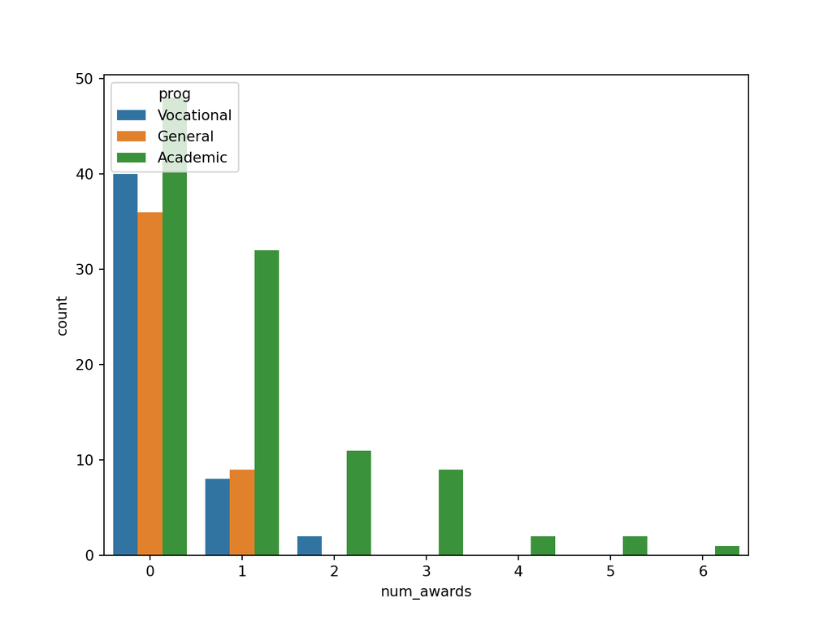

# Poisson Regression Example

Fit a model and examine result

```
## Optimization terminated successfully.
##          Current function value: 0.913761
##          Iterations 6
```

```
## <class 'statsmodels.iolib.summary.Summary'>
## """
##                           Poisson Regression Results
## ==============================================================================
## Dep. Variable:             num_awards   No. Observations:                  200
## Model:                        Poisson   Df Residuals:                      196
## Method:                           MLE   Df Model:                            3
## Date:                Thu, 27 Oct 2022   Pseudo R-squ.:                  0.2118
## Time:                        17:54:18   Log-Likelihood:                -182.75
## converged:                       True   LL-Null:                       -231.86
## Covariance Type:            nonrobust   LLR p-value:                 3.747e-21
## =========================================================================================
##                             coef    std err          z      P>|z|      [0.025      0.975]
## -----------------------------------------------------------------------------------------
## Intercept                -4.1633      0.663     -6.281      0.000      -5.462      -2.864
## C(prog)[T.General]       -1.0839      0.358     -3.025      0.002      -1.786      -0.382
## C(prog)[T.Vocational]    -0.7140      0.320     -2.231      0.026      -1.341      -0.087
## math                      0.0702      0.011      6.619      0.000       0.049       0.091
## =========================================================================================
## """
```

# Poisson Regression Example

Maximum likelihood regression lines for counts with Poisson model

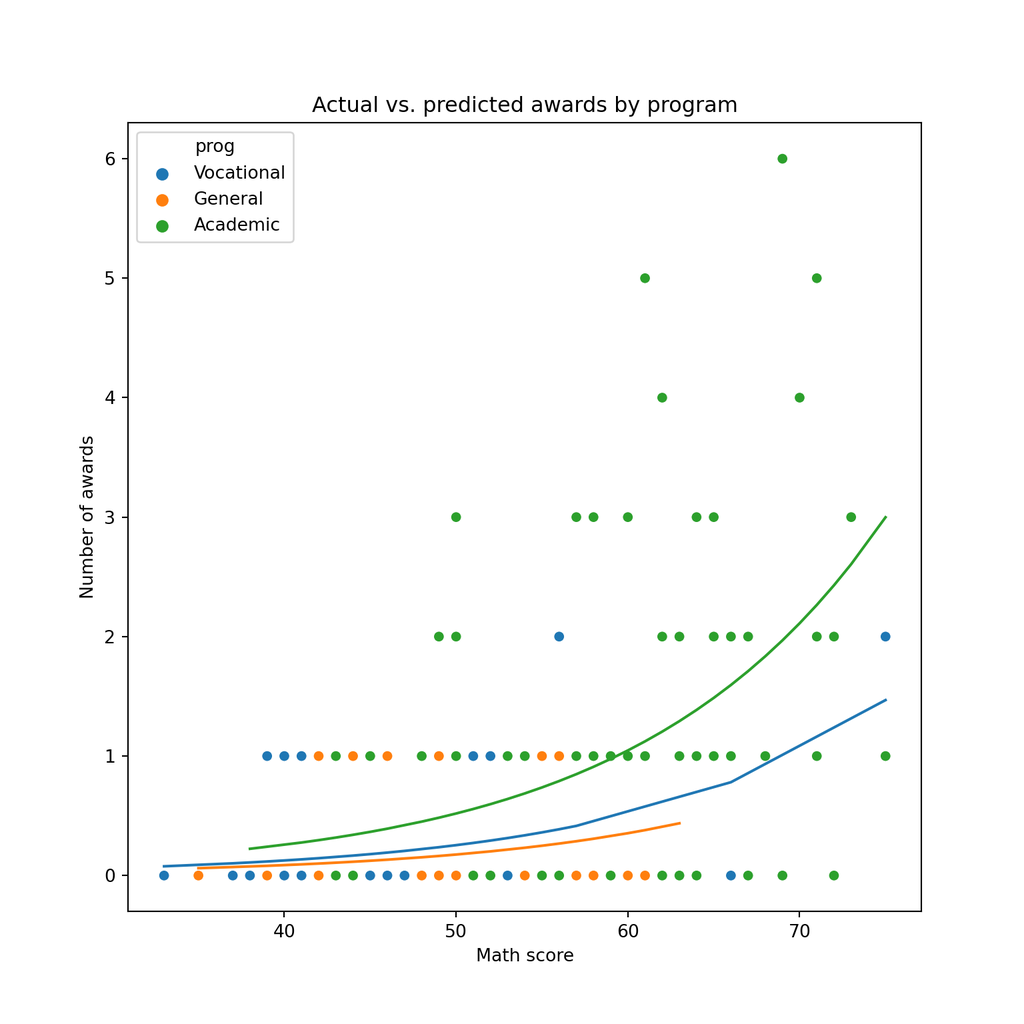

# Summary

- Models with nonlinear response have non-Normal distributions
- The generalized linear model accommodates nonlinear response distributions
- Link function transforms to linear model
  - Inverse link function transforms from Normal distribution to response distribution
- Evaluating Binomial response models
  - Confusion matrix organizes
  - Compute metrics from elements of confusion matrix
  - Use multiple evaluation criteria
- Compare model performance with deviance